# Open and Reproducible Research: Tools 3

## After merge

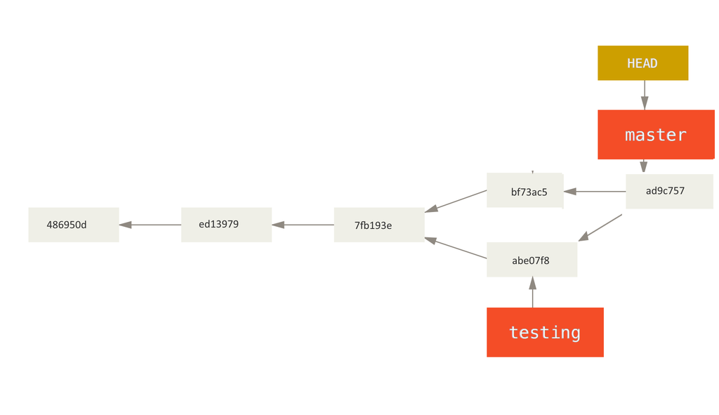

## Quiz

Indicate if the following statement is true or false:

1. In version control (VC), branching means "you diverge from the main line of development and continue to do work without messing with that main line" (T/F)
2. A branch in Git is simply a pointer to one of the commits (T/F)
3. If no merge conflicts (i.e., the same part of the same file has been modified differently depending on the branch), Git can merge branches quickly and easily (T/F)
4. Git remote branches are pointers to the branches in remote repositories, e.g. `origin/master` (T/F)

## GitHub

- GitHub is the best place to share code with friends, co-workers, and complete strangers – https://github.com/about
- a web-based Git repository hosting service launched in 2008, founded by Tom Preston-Werner, Chris Wanstrath, and PJ Hyett
- GitHub is like facebook for programmers – Karl W. Broman hadley, yihui, rdpeng, torvalds, matz, mbostock, jgm, …

## Cloning

- a public repository on GitHub can be easily `clone`d
- get a copy of all the slides for this workshop

```r
cd desktop
git clone https://github.com/Chang-Y-Chung/rr
```

## Push to a GitHub repo

Requirement: a GitHub account (sign up)

```r
> git init
> git add (many files including presentation .rmd and .html)
> git commit -m "initial commit"
> git remote add origin https://github.com/Chang-Y-Chung/rr.git
> git push -u origin master
Username for 'https://github.com':
Password for 'https://chang-y-chung@github.com':
To https://github.com/Chang-Y-Chung/rr.git
 * [new branch]      master -> master
Branch master set up to track remote branch master from origin.
```

## Pull from a GitHub repo

Once set up in the previous slide, pulling down any updates from GitHub gets simple:

```r
> git pull
Already up-to-date.
```

- `git pull` does both `git fetch` and `git merge`

## Pull request

- Creating PR: A potential collaborator
  - makes a copy of a GitHub repo under own GitHub account ("Forking")
  - pull down to local repo
  - create a PR branch and fix a bug or implement a feature
  - push the change back to own GitHub repo and
  - send the original project account a PR
- Reviewing/Accepting PR: Original project owner
  - once received a pull request, review code and documentation
  - if it is OK, then pull from the PR branch of the collaborator's GitHub repo into local master
  - once merged, push it back up to the project GitHub repo

## Creating pull request

- Diagram from Kevin Markham's [simple guide to forks](http://www.dataschool.io/simple-guide-to-forks-in-github-and-git/)

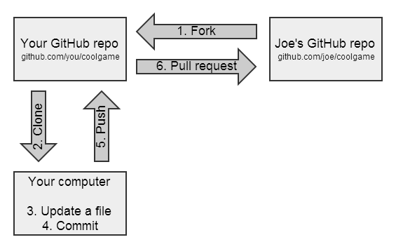

- GitHub Help on [Collaborating](https://help.github.com/categories/collaborating/)
- Hadley Wickham's writing on [RStudio, Git and GitHub](http://r-pkgs.had.co.nz/git.html).

## Git/GitHub Learning Resources

- Chacon and Straub (2014) Pro Git. Available at http://git-scm.com/book/en/v2
- Karl Broman's tutorials http://kbroman.org/pages/tutorials.html
- Gregg Pollack's Try Git video and hands-on at Code School https://www.codeschool.com/courses/try-git
- Kevin Markham's YouTube channel https://www.youtube.com/user/dataschool

## Reproducible Research Checklist

1. Are we doing good science?
2. Was any part of this analysis done by hand?
3. Have we taught a computer to do as much as possible (i.e. coded)?
4. Are we using a version control system?
5. Have we documented our software environment?
6. Have we saved any output that we cannot reconstruct from original data + code?
7. How far back in the analysis pipeline can we go before our results are no longer (automatically) reproducible?

Roger Peng (2014) "Reproducible Research Checklist" Lecture note for the Coursera Course titled "Reproducible Research". Accessed at https://github.com/rdpeng/courses on Jan, 2015.

## Quiz

True or False?

1. If any part of the analysis was done by hand, then the research is not reproducible. (T/F)
2. It is a good idea to call `sessionInfo()` in your R code. (T/F)
3. Always make sure to call `set.seed()`; Feel free to call `date()`. (T/F)

## The End

- Any questions?
- Please fill out the feedback form. Thanks a lot!